# Análise Exploratória de Vinhos Espanhóis

Escolhemos a base de dados [Spanish Wine Quality Dataset](https://www.kaggle.com/datasets/fedesoriano/spanish-wine-quality-dataset). Além de ser um assunto interessante, a base possui variáveis de todos os tipos, possibilitando o uso de uma maior variedade de ferramentas analíticas.  
Os dados foram importados para Excel para a limpeza. Os seguintes passos foram seguidos:

- A coluna país foi removida por só haver um país.
- A coluna preço foi formatada.
- Foram removidos os dados sem informação de ano.
- Vinhos com valores superiores a 10 000 000 de euros foram desconsiderados.
- Vinhos sem tipo, corpo e acidez especificados foram desconsiderados.
- A coluna rating foi formatada como número.

```r
library(tidyverse)
library(readr)

vinho <- read_delim("Vinos de España.csv",
    delim = ";", escape_double = FALSE, trim_ws = TRUE)
head(vinho)
```

| Winery | Wine | Year | Rating | Num_reviews | Region | Price | Type | Body | Acidity |
| --- | --- | --- | --- | --- | --- | --- | --- | --- | --- |
| Bodegas Faustino | I Gran Reserva | 1994 | 4.2 | 2074 | Rioja | 124.5 | Rioja Red | 4 | 3 |
| La Rioja Alta | Vina Ardanza Reserva | 2000 | 4.2 | 883 | Rioja | 161.0 | Rioja Red | 4 | 3 |
| Muga | Seleccion Especial (Reserva) | 2004 | 4.2 | 447 | Rioja | 65.0 | Rioja Red | 4 | 3 |
| Imperial | Rioja Reserva | 2004 | 4.2 | 417 | Rioja | 45.0 | Rioja Red | 4 | 3 |
| Imperial | Rioja Reserva | 2004 | 4.2 | 417 | Rioja | 45.0 | Rioja Red | 4 | 3 |
| Imperial | Rioja Reserva | 2004 | 4.2 | 417 | Rioja | 45.0 | Rioja Red | 4 | 3 |

Pesquisando sobre as regiões, descobrimos que há casos de municípios, de microrregiões de províncias e de denominações de origem protegida (indicação oficial da União Europeia que visa a certificar produtos de culinárias tradicionais). Por causa disso, a análise dos dados de região não poderá ser tão exata, ficando impossibilitada, por exemplo, a produção de mapas.

Inicialmente, pensamos em tentar enteder que fatores estão relacionados com o preço e com a avaliação do vinho, ou seja, o que faz um vinho ser caro e o que o faz ser bem-avaliado.

# Análises unidimensionais

```r
summary(vinho)
```

```
    Winery              Wine                Year          Rating       Num_reviews
 Length:6022        Length:6022        Min.   :1910   Min.   :4.200   Min.   :   25.0
 Class :character   Class :character   1st Qu.:2011   1st Qu.:4.200   1st Qu.:  388.0
 Mode  :character   Mode  :character   Median :2015   Median :4.200   Median :  402.0
                                       Mean   :2013   Mean   :4.259   Mean   :  438.5
                                       3rd Qu.:2017   3rd Qu.:4.200   3rd Qu.:  417.0
                                       Max.   :2021   Max.   :4.900   Max.   :16505.0
    Region              Price             Type                Body
 Length:6022        Min.   :   6.26   Length:6022        Min.   :2.000
 Class :character   1st Qu.:  19.98   Class :character   1st Qu.:4.000
 Mode  :character   Median :  31.63   Mode  :character   Median :4.000
                    Mean   :  67.35                      Mean   :4.162
                    3rd Qu.:  61.94                      3rd Qu.:5.000
                    Max.   :3119.08                      Max.   :5.000
    Acidity
 Min.   :1.000
 1st Qu.:3.000
 Median :3.000
 Mean   :2.947
 3rd Qu.:3.000
 Max.   :3.000
```

```r
sd(vinho$Year)
```

```
[1] 7.164183
```

```r
sd(vinho$Rating)
```

```
[1] 0.1246105
```

```r
sd(vinho$Num_reviews)
```

```
[1] 600.7005
```

```r
sd(vinho$Price)
```

```
[1] 165.9659
```

```r
sd(vinho$Body)
```

```
[1] 0.5941001
```

```r
sd(vinho$Acidity)
```

```
[1] 0.243499
```

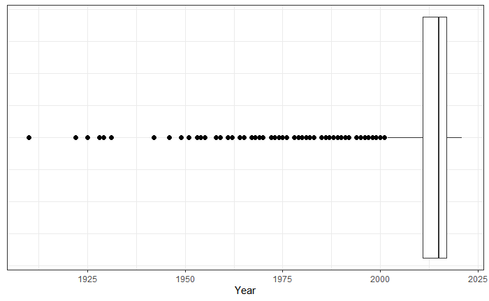

```r
z <- ggplot(vinho, aes(x = Year))
z + geom_boxplot(outlier.colour="black", outlier.shape=16, outlier.size=2) +
  theme_bw() +
  theme(axis.text.y = element_blank(), axis.ticks.y = element_blank())
```

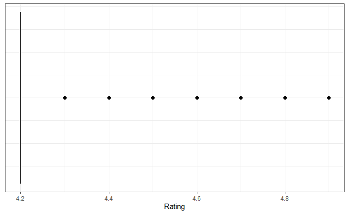

```r
y <- ggplot(vinho, aes(x = Rating))
y + geom_boxplot(outlier.colour="black", outlier.shape=16, outlier.size=2) +
  theme_bw() +
  theme(axis.text.y = element_blank(), axis.ticks.y = element_blank())
```

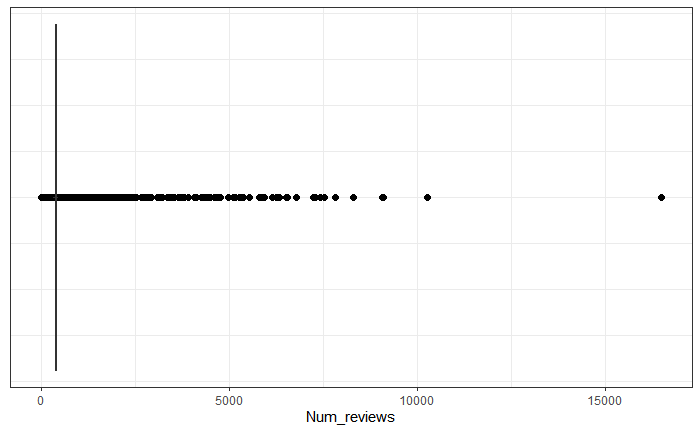

```r
x <- ggplot(vinho, aes(x = Num_reviews))
x + geom_boxplot(outlier.colour="black", outlier.shape=16, outlier.size=2) +
  theme_bw() +
  theme(axis.text.y = element_blank(), axis.ticks.y = element_blank())
```

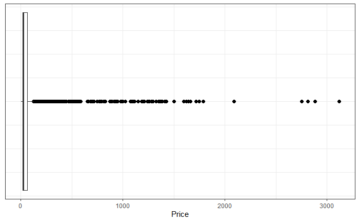

```r
w <- ggplot(vinho, aes(x = Price))
w + geom_boxplot(outlier.colour="black", outlier.shape=16, outlier.size=2) +
  theme_bw() +
  theme(axis.text.y = element_blank(), axis.ticks.y = element_blank())
```

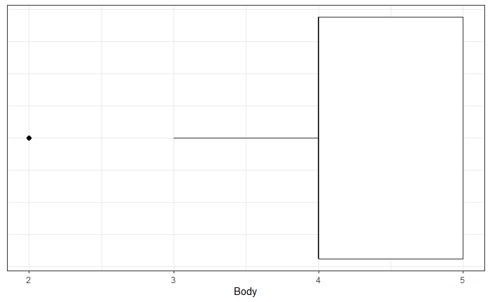

```r
v <- ggplot(vinho, aes(x = Body))
v + geom_boxplot(outlier.colour="black", outlier.shape=16, outlier.size=2) +
  theme_bw() +
  theme(axis.text.y = element_blank(), axis.ticks.y = element_blank())
```

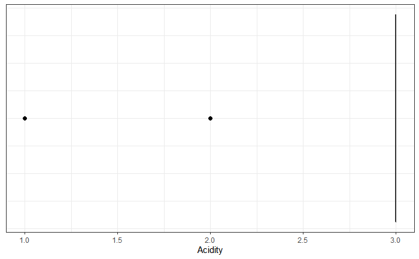

```r
u <- ggplot(vinho, aes(x = Acidity))
u + geom_boxplot(outlier.colour="black", outlier.shape=16, outlier.size=2) +
  theme_bw() +
  theme(axis.text.y = element_blank(), axis.ticks.y = element_blank())
```

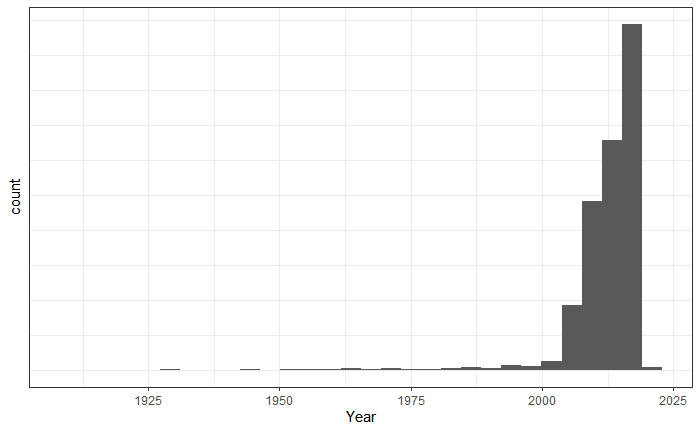

```r
t <- ggplot(vinho, aes(x = Year))
t + geom_histogram() +
  theme_bw() +
  theme(axis.text.y = element_blank(), axis.ticks.y = element_blank())
```

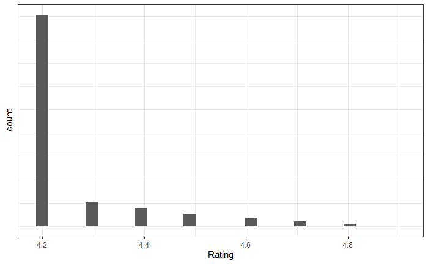

```r
s <- ggplot(vinho, aes(x = Rating))
s + geom_histogram() +
  theme_bw() +
  theme(axis.text.y = element_blank(), axis.ticks.y = element_blank())
```

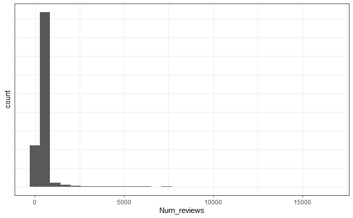

```r
r <- ggplot(vinho, aes(x = Num_reviews))
r + geom_histogram() +
  theme_bw() +
  theme(axis.text.y = element_blank(), axis.ticks.y = element_blank())
```

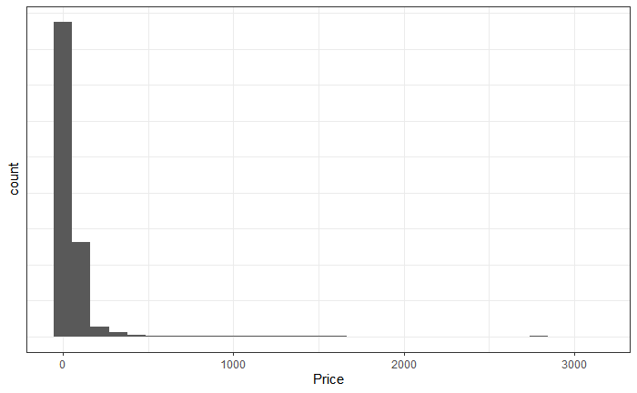

```r
q <- ggplot(vinho, aes(x = Price))
q + geom_histogram() +
  theme_bw() +
  theme(axis.text.y = element_blank(), axis.ticks.y = element_blank())
```

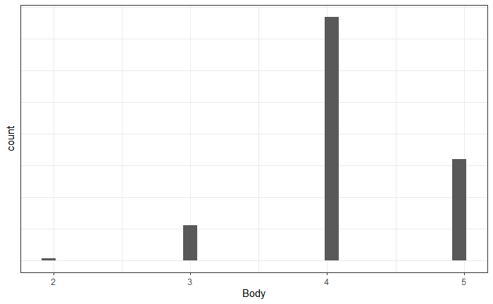

```r
p <- ggplot(vinho, aes(x = Body))
p + geom_histogram() +
  theme_bw() +
  theme(axis.text.y = element_blank(), axis.ticks.y = element_blank())
```

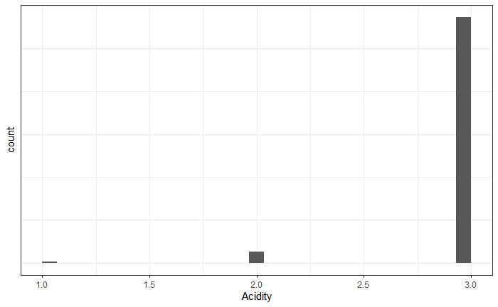

```r
o <- ggplot(vinho, aes(x = Acidity))
o + geom_histogram() +
  theme_bw() +
  theme(axis.text.y = element_blank(), axis.ticks.y = element_blank())
```

# Algumas análises preliminares

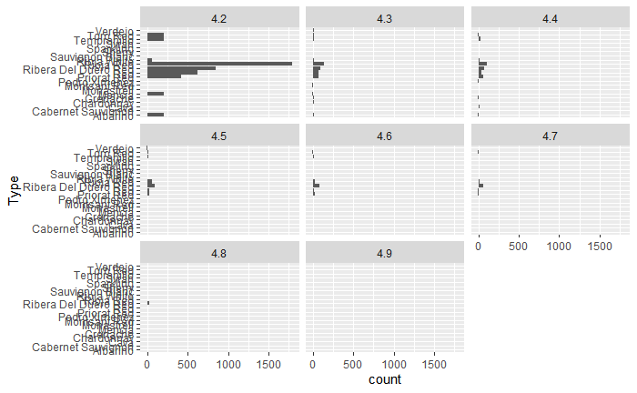

```r
n <- ggplot(vinho, aes(y = Type)) +
  geom_bar() + facet_wrap(~Rating)
n
```

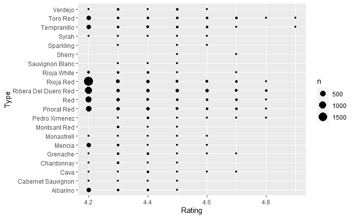

```r
m <- ggplot(vinho, aes(x = Rating, y = Type)) +
  geom_count()
m
```

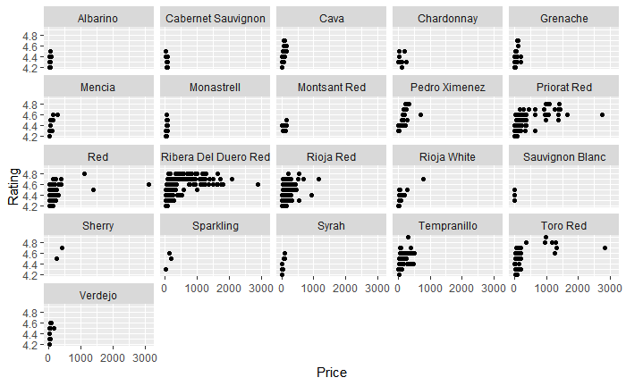

```r
l <- ggplot(vinho, aes(x = Price, y = Rating)) +
  geom_point() + facet_wrap(~Type)
l
```

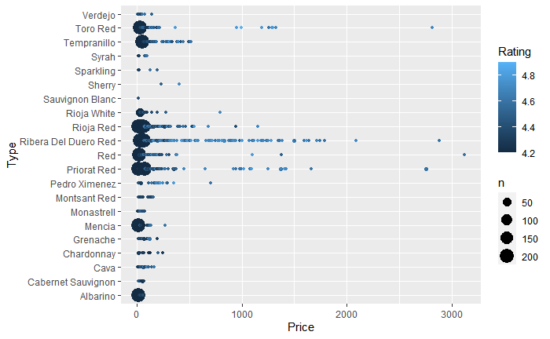

```r
k <- ggplot(vinho, aes(x = Price, y = Type, color = Rating)) +
  geom_count()
k
```

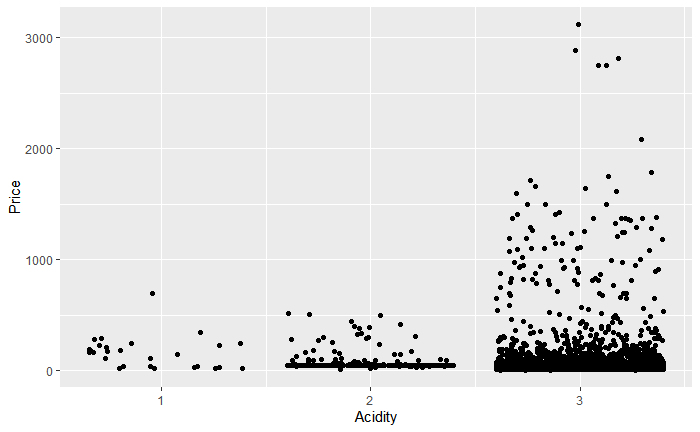

```r
j <- ggplot(vinho, aes(y = Price, x = Acidity))
j + geom_jitter()
```

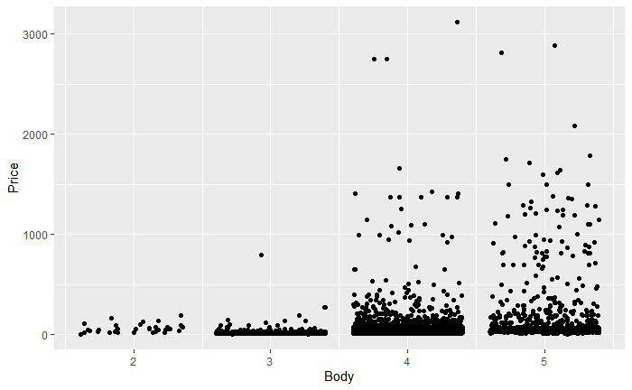

```r
h <- ggplot(vinho, aes(y = Price, x = Body))
h + geom_jitter()
```

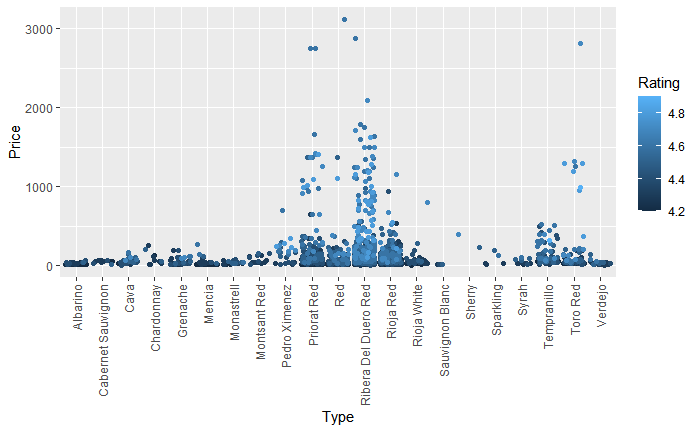

```r
g <- ggplot(vinho, aes(y = Price, x = Type, color = Rating))
g + geom_jitter() + theme(axis.text.x = element_text(angle = 90, vjust = 0.5, hjust=1))
```

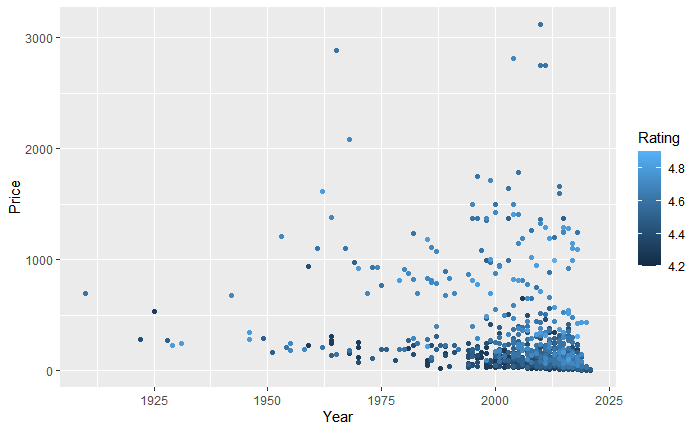

```r
f <- ggplot(vinho, aes(y = Price, x = Year, color = Rating))
f + geom_point()
```